# §2.2a — Daily Motion

Unit 2: The Night Sky · Astronomy

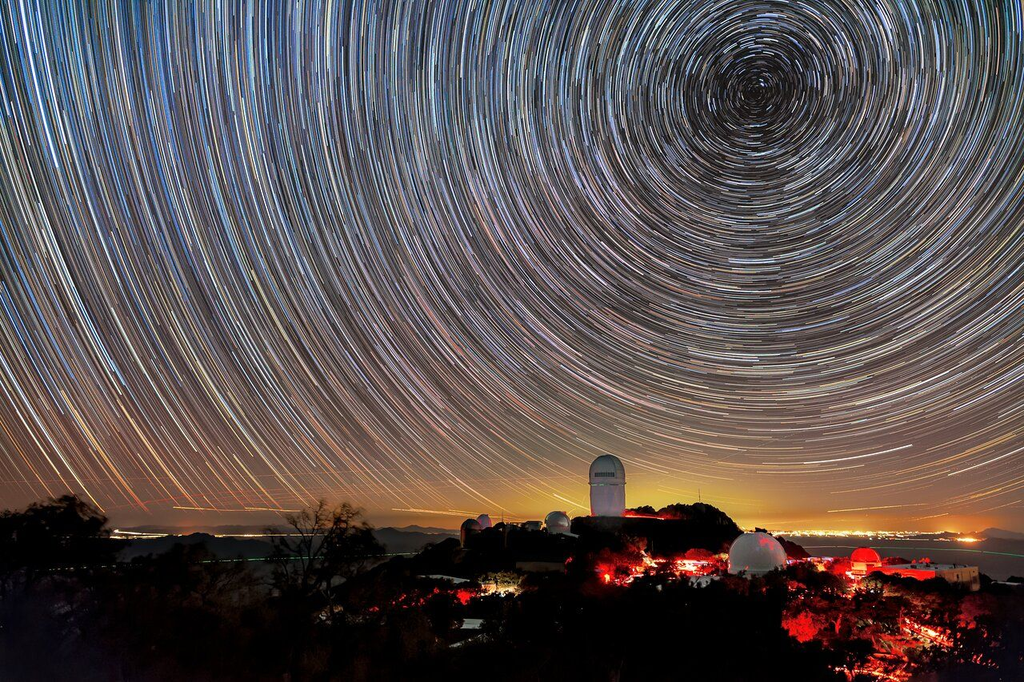

Leave a camera open for an hour, pointed north. Every star draws a piece of a circle, and all the circles share one still centre. That centre is the North Celestial Pole, and Polaris sits almost on it.

Here the centre sits about a third of the way up the sky. Why there, and not straight overhead? And why do some of these stars never reach the ground?

Today: how the stars move during one night, and how that depends on where you stand.

Star trails over Kitt Peak. Photo: KPNO/NOIRLab/NSF/AURA/B. Tafreshi (CC BY 4.0)

## 1 · Daily motion at a glance

🧭

The altitude of the NCP

is your latitude

📍

Portland's latitude

so Polaris sits about halfway up the northern sky

⭕

Never set from Portland

circumpolar: the Big Dipper's Dubhe is one

🚫

Never rise from Portland

Canopus, the second-brightest star, is one

⬆️

Maximum altitude

how high a star gets when it transits

## 2 · How the stars move

Click a tile. Each one tips the sky a little further from the North Pole toward Portland.

[figure not shown]

1

Star tracks

the sky in one long exposure

[figure not shown]

2

Daily Motion at North Pole

latitude = 90° N

[figure not shown]

3

Tilting the Earth

from the North Pole to the Equator

[figure not shown]

4

Daily Motion in Seattle

and in Portland

[figure not shown]

5

Visibility and Circumpolar Stars

always, sometimes, never; how high

← scroll the tiles →

[figure not shown]

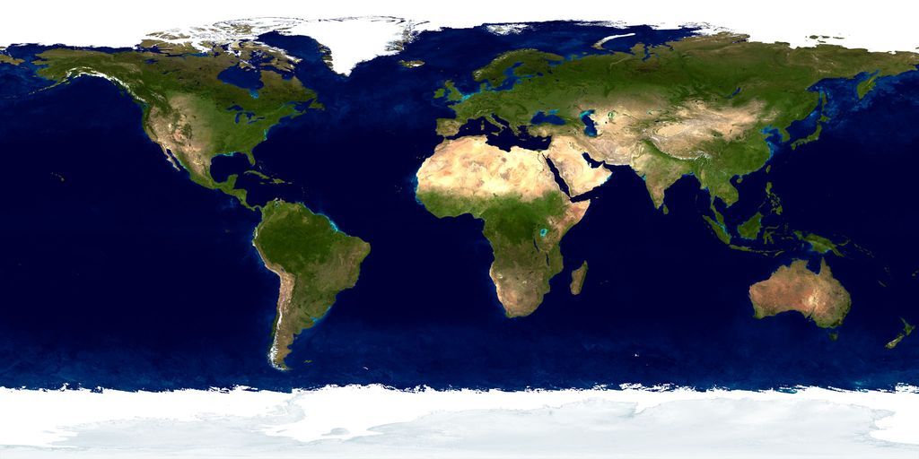

### Star tracks

**As the Earth spins around its axis, stars appear to move.** One turn takes a day, so every star sweeps $\frac{360^\circ}{24\ {\rm h}} = 15^\circ$ per hour.

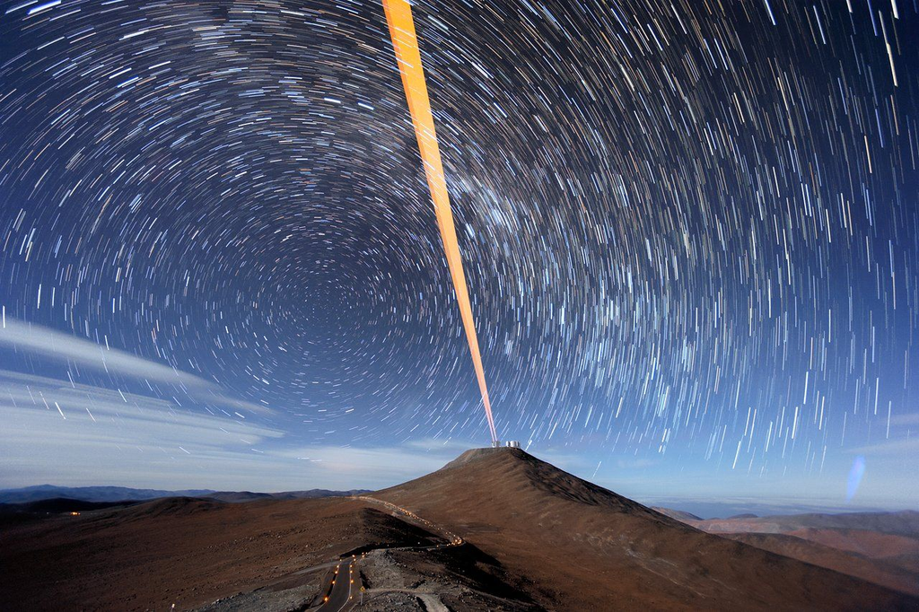

Chile, 24.6° S. These tracks circle the **South** Celestial Pole, low in the sky. ESO/F. Kamphues (CC BY 4.0)

Your own long exposure

Predict first. Facing north, the stars turn around Polaris…

[interactive chart not shown]

Facing:From:

exposure0 h

Choose a prediction to open the shutter. The bright dot on each track is where the star is now.

Measure: how long was the exposure?

One star's track sweeps $60^\circ$ around Polaris. How long was the shutter open?

h

### Daily Motion at North Pole

This drawing is a **horizon diagram**. You stand in the middle; the dome is your sky; south is on the left and north on the right. **Altitude** $=\theta=$ the angle above the horizon. Straight up is the **Zenith** (straight down is the **Nadir**). The **Meridian** runs from south, through the zenith, to north.

At the North Pole: $\theta_{\rm NCP} = 90^\circ$ and $\theta_{\rm CE} = 0^\circ$.  
Stars with $\delta > 0^\circ$ never set (**circumpolar**). Stars with $\delta < 0^\circ$ never rise (not visible).

Move the star, keep its track

Measure: read a declination from the sky

At the North Pole, a star circles the sky at a steady altitude of $67.5^\circ$. Drag the star’s circle above to test your answer. What is its declination?

°

### Tilting the Earth from NP to the Equator

**Moving from the North Pole to the Equator is like tilting the Earth by $90^\circ$.** Drag yourself down the globe and watch your horizon tip with you. Your latitude is the angle at Earth's centre, from the equator to you. Your NCP points the same way from everywhere (straight up the axis), so its altitude above your horizon is your latitude, and its tilt from your zenith is $90 - {\rm lat}$.

The altitude of the NCP is your latitude! $$\boxed{\theta_{\rm NCP} = {\rm lat}}$$

Your place on Earth: drag yourself or the star

[interactive chart not shown]

Your sky: drag the pole or the star

[interactive chart not shown]

Stand in:

latitude

**Daily Motion at the Equator** (latitude $=0^\circ$ N): $\theta_{\rm NCP}=0^\circ$, on the horizon, and $\theta_{\rm CE}=90^\circ$, overhead. No stars are circumpolar, but all are visible at some point in the day-night cycle. All stars stay up for 12 h.

Measure: where are you?

You measure Polaris $37^\circ$ above the northern horizon in San Francisco. What is San Francisco's latitude?

° N

### Daily Motion in Seattle

Seattle is at latitude $=47^\circ$ N, Portland at $45.5^\circ$ N. Between the two extremes, the sky is tipped. Four things to look for on the diagram:

1. The CE rises due E and sets due W.
2. Stars going through the zenith have $\delta =$ latitude.
3. **Circumpolar circles** (purple). *Northern:* $\delta > 90 - {\rm lat}$ are stars that never set. *Southern:* just flip the sign: $\delta < -(90 - {\rm lat})$ are stars that never rise.
4. **Maximum altitude:** $\boxed{\theta_{\rm max} = 90 - |{\rm lat} - \delta|}$. A star reaches it when it **transits**, crossing the meridian.

The sky from anywhere

Measure: the circumpolar limit in Anchorage

Anchorage is at latitude $61^\circ$ N. Stars with $\delta$ greater than what never set?

°

### Visibility and Circumpolar Stars

A star is **circumpolar** if it never sets. A star is **visible** if you can sometimes see it. So a star can be visible without being circumpolar, and that depends on where you stand.

Sky Explorer: check it on the globe

Click a star's name in the sort below to put it here. A star in the green cap never sets, a star in the red cap never rises, and everything between rises and sets. On the left the sky stays put and you turn with the Earth. On the right you stay put and the sky turns.

Always, Sometimes or Never Visible?

From:

[interactive chart not shown]

**How high does it get? Think in terms of the CE.** At latitude $40^\circ$ N you are $50^\circ$ from the pole, so the CE is tipped up $50^\circ$ from where it sat at the North Pole. A star with $\delta = +20^\circ$ rides $20^\circ$ above the CE. So it transits at $50 + 20 = 70^\circ$. That is the same as $\theta_{\rm max} = 90 - |{\rm lat} - \delta|$.

Count up from the CE: drag the star

[interactive chart not shown]

latitude

star's δ

Measure: how high does Aldebaran get?

Aldebaran has $\delta = +16.5^\circ$. Find $\theta_{\rm max}$ from Portland, latitude $45.5^\circ$ N.

°

**Look up on Tue Nov 10.** Sunset is 4:45 pm. **Deneb** ($\delta = +45^\circ 16'$) transits at 5:32 pm, $89.9^\circ$ up: from Portland it passes nearly through the zenith. **Saturn** is $45^\circ$ up and almost due south at 9 pm, with the Moon already down. Find Polaris, then hold your fists at arm's length, about $10^\circ$ each: it should be about 4½ fists up. Worth a sketch: the Big Dipper, low in the north that evening and never setting.

## 3 · Where am I?

Read the tracks: which latitude?

[interactive chart not shown]

## 4 · Self-check

**Sources and further reading**

Want to dig deeper? Each title links straight to the original.

**Star tracks**

- [A Colorful Night](https://noirlab.edu/public/images/iotw2025a/) (NOIRLab): the photo at the top, with why the trails have different colours.
- [Trails of Stars over Paranal](https://www.eso.org/public/images/potw2040a/) (ESO): the Chile photo, and how it was stacked from many exposures.

**The sky from where you stand**

- [Circumpolar stars](https://en.wikipedia.org/wiki/Circumpolar_star) (Wikipedia): why they never set, and how that changes with latitude.
- [Diurnal motion](https://en.wikipedia.org/wiki/Diurnal_motion) (Wikipedia): the daily turning of the sky, with photos facing each direction.
- [Skywatching](https://science.nasa.gov/skywatching/) (NASA): what's up in the sky each month, with charts.

**Tonight's sky**

- [Astronomy Engine](https://github.com/cosinekitty/astronomy) (Don Cross): the code that computed Portland's transit times on this page.
- d3-celestial (Olaf Frohn): the star positions in the Real sphere.
- [The Blue Marble](https://visibleearth.nasa.gov/images/57730/the-blue-marble-land-surface-ocean-color-and-sea-ice) (NASA): the map of the whole Earth used on the tilting globe.

**Image credits**

- Star trails over Kitt Peak: KPNO/NOIRLab/NSF/AURA/B. Tafreshi (CC BY 4.0).
- Star trails over Paranal: ESO/F. Kamphues (CC BY 4.0).
- Stars in the Real sphere: Hipparcos, via d3-celestial (BSD-3). Stick figures: after H.A. Rey, from the Stellarium `western_rey` sky culture (CC BY-SA 4.0).
- Earth on Tilting the Earth: Blue Marble, NASA Goddard Space Flight Center (Reto Stöckli), public domain.
- All other figures are drawn on this page.